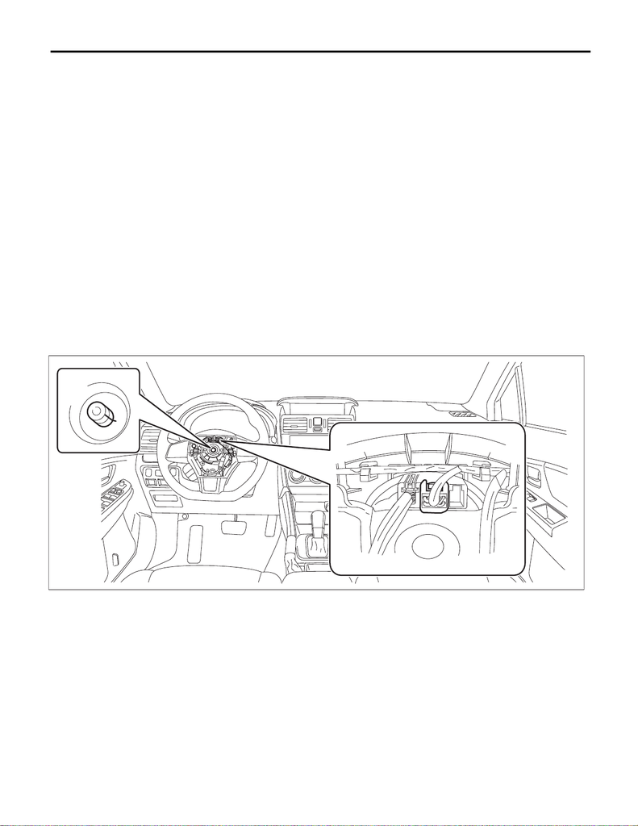

PS-16

Steering Wheel

POWER ASSISTED SYSTEM (POWER STEERING)

3. Steering Wheel

A: REMOVAL

CAUTION:

Before performing service on the airbag module, always refer to “CAUTION” of “General Descrip-

tion” in “AIRBAG SYSTEM” section. <Ref. to AB-9, CAUTION, General Description.>

1) Disconnect the ground cable from battery and wait for at least 60 seconds before starting work. <Ref. to

NT-5, BATTERY, NOTE, Note.>

NOTE:

For models other than STI model, disconnect the ground terminal from battery sensor.

2) Set the tire to the straight-ahead position.

3) Remove the driver’s airbag module. <Ref. to AB-33, REMOVAL, Driver’s Airbag Module.>

4) Remove the steering wheel.

CAUTION:

• Always use the steering wheel puller for removal to avoid deforming the steering wheel.

• If the steering wheel has been removed, make sure that the steering roll connector is not turned

from the original position.

(1) Disconnect the connector and remove the nut.

(2) Put alignment marks and remove the steering wheel.

Preparation tool:

Steering wheel puller

PS-01722

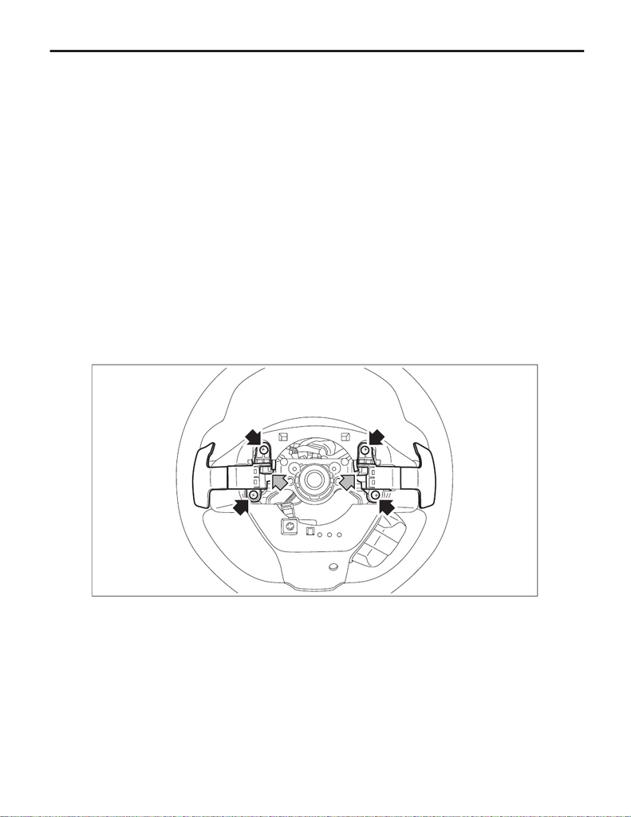

PS-17

Steering Wheel

POWER ASSISTED SYSTEM (POWER STEERING)

B: INSTALLATION

CAUTION:

• Before handling the airbag module, refer to “CAUTION” of “General Description” in “AIRBAG SYS-

TEM”. <Ref. to AB-9, CAUTION, General Description.>

• If the steering wheel has been removed, make sure that the steering roll connector is not turned

from the original position.

• If the steering wheel and steering angle sensor are removed, perform “VDC sensor midpoint set-

ting mode” of the VDC. <Ref. to VDC-16, VDC SENSOR MIDPOINT SETTING MODE, ADJUSTMENT,

VDC Control Module and Hydraulic Control Unit (VDCCM&H/U).>

1) Align the center position of the roll connector. <Ref. to AB-64, ADJUSTMENT, Roll Connector.>

2) Install the steering wheel.

Tightening torque:

Steering wheel: 39 N·m (4.0 kgf-m, 28.8 ft-lb)

Clearance:

Between cover assembly - column and steering wheel: 4 — 6 mm (0.16 — 0.24 in)

3) Install the driver’s airbag module. <Ref. to AB-34, INSTALLATION, Driver’s Airbag Module.>

4) Connect the battery ground terminal. <Ref. to NT-5, BATTERY, NOTE, Note.>

NOTE:

For models other than STI model, connect the ground terminal to battery sensor.

C: DISASSEMBLY

1) Remove the screw, disconnect the connector and remove the paddle shift switch. (Model with paddle shift)

PS-01719

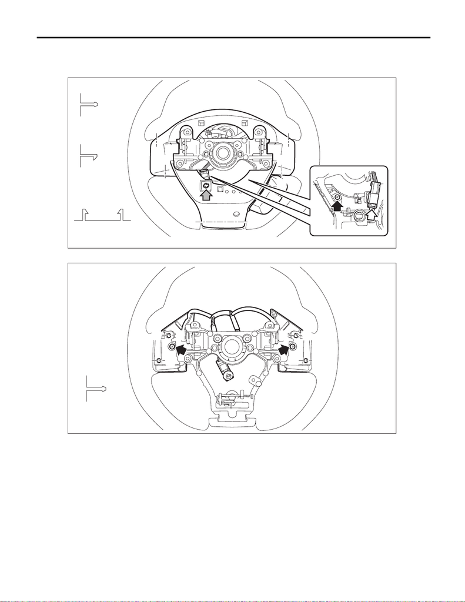

PS-18

Steering Wheel

POWER ASSISTED SYSTEM (POWER STEERING)

2) Release the claws and clips, detach the cover - steering wheel LWR.

NOTE:

For model with steering switch, remove the connector and screw.

3) Remove the screws and detach the satellite switch.

PS-01721

B

B

A

A

A

A

B

B

C

C

PS-01764

A-A

A

A

A

A

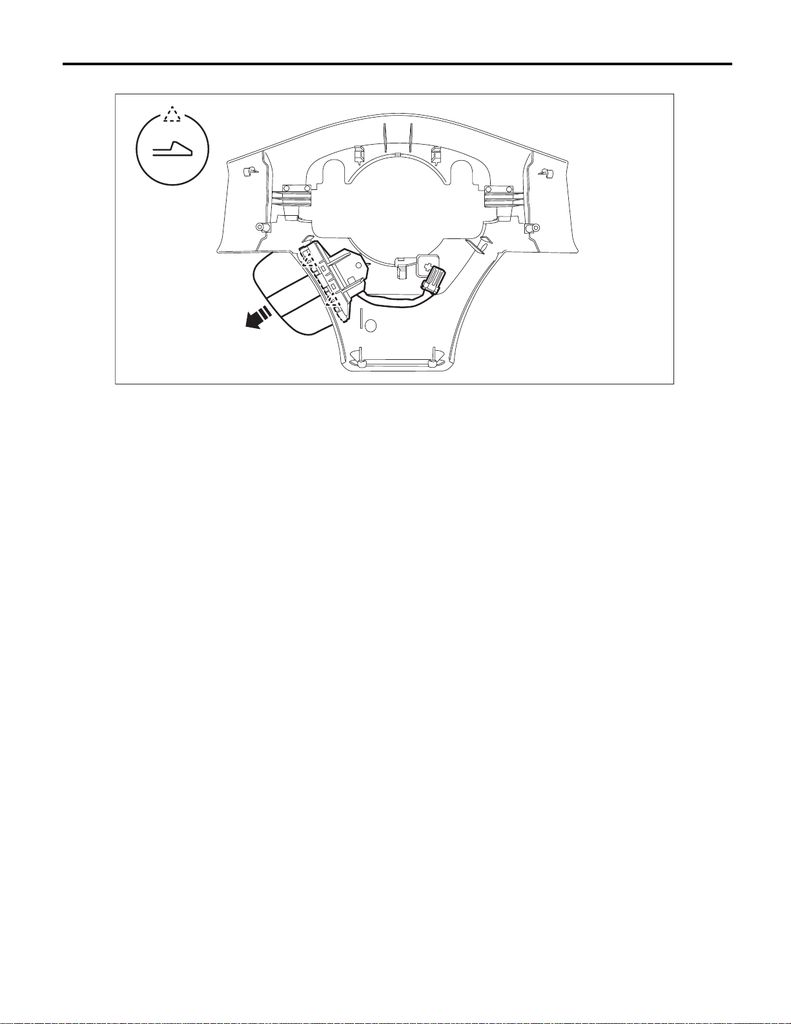

PS-19

Steering Wheel

POWER ASSISTED SYSTEM (POWER STEERING)

4) Remove the MID switch.

D: ASSEMBLY

CAUTION:

Securely install the switch. Improper insertion of the pin or claw of the switch may cause improper

installation.

1) Install the MID switch.

2) Install the satellite switch.

3) Install the cover - steering wheel LWR.

4) Install the paddle shift switch. (Model with paddle shift)

IDI00449

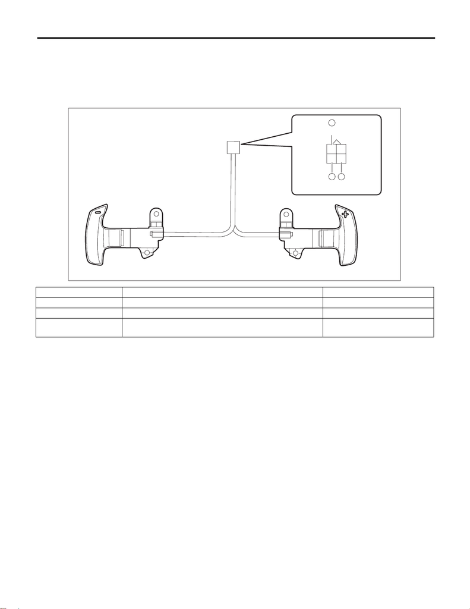

PS-20

Steering Wheel

POWER ASSISTED SYSTEM (POWER STEERING)

E: INSPECTION

1. PADDLE SHIFT SWITCH

1) Measure the resistance between connector terminals.

Preparation tool:

Circuit tester

2) Replace the paddle shift switch if the inspection result is not within the standard value.

2. SATELLITE SWITCH ASSEMBLY

Refer to “Steering Satellite Switch” of “ENTERTAINMENT” section. <Ref. to ET-17, INSPECTION, Steering

Satellite Switch.>

3. MID SWITCH

Refer to “Steering Switch” of “INSTRUMENTATION/DRIVER INFO” section. <Ref. to IDI-25, INSPECTION,

Steering Switch.>

Terminal No. Inspection conditions Standard

3 — 4 Operate the + side of paddle shift assembly and hold it. Less than 10 Ω

2 — 3 Operate the – side of paddle shift assembly and hold it. Less than 10 Ω

Do not operate the paddle shift assembly. Is the resistance 1 MΩ or more?

GND

DOWN

2

2

4

UP

3

PS-01727